# **TikTok Project**

**Course 3 - Go Beyond the Numbers: Translate Data into Insights**

Your TikTok data team is still in the early stages of their latest project. So far, you’ve completed a project proposal and used Python to inspect and organize the TikTok dataset.

Orion Rainier, a Data Scientist at TikTok, is pleased with the work you have already completed and is requesting your assistance with some Exploratory Data Analysis (EDA) and data visualization. The management team asked to see a Python notebook showing data structuring and cleaning, as well as any matplotlib/seaborn visualizations plotted to help us understand the data. At the very least, include a graph comparing claim counts to opinion counts, as well as boxplots of the most important variables (like “video duration,” “video like count,” “video comment count,” and “video view count”) to check for outliers. Also, include a breakdown of “author ban status” counts.

Additionally, the management team has recently asked all EDA to include Tableau visualizations. Tableau visualizations are particularly helpful in status reports to the client and board members. For this data, create a Tableau dashboard showing a simple claims versus opinions count, as well as stacked bar charts of claims versus opinions for variables like video view counts, video like counts, video share counts, and video download counts. Make sure it is easy to understand to someone who isn’t data savvy, and remember that the assistant director is a person with visual impairments.

You also notice a follow-up email from the Data Science Lead, Willow Jaffey. Willow suggests including an executive summary of your analysis to share with teammates.

A notebook was structured and prepared to help you in this project. Please complete the following questions.

# **Course 3 End-of-course project: Exploratory data analysis**

In this activity, you will examine data provided and prepare it for analysis. You will also design a professional data visualization that tells a story, and will help data-driven decisions for business needs.

Please note that the Tableau visualization activity is optional, and will not affect your completion of the course. Completing the Tableau activity will help you practice planning out and plotting a data visualization based on a specific business need. The structure of this activity is designed to emulate the proposals you will likely be assigned in your career as a data professional. Completing this activity will help prepare you for those career moments.

**The purpose** of this project is to conduct exploratory data analysis on a provided data set. Your mission is to continue the investigation you began in C2 and perform further EDA on this data with the aim of learning more about the variables. Of particular interest is information related to what distinguishes claim videos from opinion videos.

**The goal** is to explore the dataset and create visualizations.  
*This activity has 4 parts:*

**Part 1:** Imports, links, and loading

**Part 2:** Data Exploration

- Data cleaning

**Part 3:** Build visualizations

**Part 4:** Evaluate and share results

Follow the instructions and answer the question below to complete the activity. Then, you will complete an executive summary using the questions listed on the PACE Strategy Document.

Be sure to complete this activity before moving on. The next course item will provide you with a completed exemplar to compare to your own work.

# **Visualize a story in Tableau and Python**

# **PACE stages**

Throughout these project notebooks, you'll see references to the problem-solving framework PACE. The following notebook components are labeled with the respective PACE stage: Plan, Analyze, Construct, and Execute.

## **PACE: Plan**

Consider the questions in your PACE Strategy Document and those below where applicable to craft your response:

1. Identify any outliers:
- What methods are best for identifying outliers?
- How do you make the decision to keep or exclude outliers from any future models?

### **Task 1. Imports, links, and loading**

Go to Tableau Public The following link will help you complete this activity. Keep Tableau Public open as you proceed to the next steps.

Link to supporting materials: Public Tableau: https://public.tableau.com/s/. Note that the TikTok dataset can be downloaded directly from this notebook by going to "Lab Files" in the menu bar at the top of the page, clicking into the "/home/jovyan/work" folder, selecting `tiktok_dataset.csv`, and clicking "Download" above the list of files.

For EDA of the data, import the packages that would be most helpful, such as `pandas`, `numpy`, `matplotlib.pyplot`, and `seaborn`.

```python
# Import packages for data manipulation
import pandas as pd
import numpy as np

# Import packages for data visualization
import matplotlib.pyplot as plt
import seaborn as sns
```

Then, load the dataset into a dataframe. Read in the data and store it as a dataframe object.

**Note:** As shown in this cell, the dataset has been automatically loaded in for you. You do not need to download the .csv file, or provide more code, in order to access the dataset and proceed with this lab. Please continue with this activity by completing the following instructions.

```python
# Load dataset into dataframe
data = pd.read_csv("tiktok_dataset.csv")
```

## **PACE: Analyze**

Consider the questions in your PACE Strategy Document and those below where applicable to complete your code.

### **Task 2a: Data exploration and cleaning**

The first step is to assess your data. Check the Data Source page on Tableau Public to get a sense of the size, shape and makeup of the data set.

Consider functions that help you understand and structure the data.

- `.head()`
- `.info()`
- `.describe()`
- `.groupby()`
- `.sort_values()`

Consider the following questions as you work:

What do you do about missing data (if any)?

Are there data outliers?

Start by discovering, using `.head()`, `.size`, and `.shape`.

```python
print("First 5 rows of the DataFrame:")
print(data.head())
```

```
First 5 rows of the DataFrame:
   # claim_status    video_id  video_duration_sec  \
0  1        claim  7017666017                  59
1  2        claim  4014381136                  32
2  3        claim  9859838091                  31
3  4        claim  1866847991                  25
4  5        claim  7105231098                  19

                            video_transcription_text verified_status  \
0  someone shared with me that drone deliveries a...    not verified
1  someone shared with me that there are more mic...    not verified
2  someone shared with me that american industria...    not verified
3  someone shared with me that the metro of st. p...    not verified
4  someone shared with me that the number of busi...    not verified

  author_ban_status  video_view_count  video_like_count  video_share_count  \
0      under review          343296.0           19425.0              241.0
1            active          140877.0           77355.0            19034.0
2            active          902185.0           97690.0             2858.0
3            active          437506.0          239954.0            34812.0
4            active           56167.0           34987.0             4110.0

   video_download_count  video_comment_count
0                   1.0                  0.0
1                1161.0                684.0
2                 833.0                329.0
3                1234.0                584.0
4                 547.0                152.0
```

```python
# Get the total number of elements in the DataFrame
print("\nTotal number of elements (size):", data.size)
```

```
Total number of elements (size): 232584
```

```python
# Get the dimensions of the DataFrame (number of rows and columns)
print("\nShape of the DataFrame (rows, columns):", data.shape)
```

```
Shape of the DataFrame (rows, columns): (19382, 12)
```

Get basic information about the data, using `.info()`.

```python
# Get basic information about the data, including data types and non-null values
print(data.info())
```

```
<class 'pandas.core.frame.DataFrame'>
RangeIndex: 19382 entries, 0 to 19381
Data columns (total 12 columns):
 #   Column                    Non-Null Count  Dtype
---  ------                    --------------  -----
 0   #                         19382 non-null  int64
 1   claim_status              19084 non-null  object
 2   video_id                  19382 non-null  int64
 3   video_duration_sec        19382 non-null  int64
 4   video_transcription_text  19084 non-null  object
 5   verified_status           19382 non-null  object
 6   author_ban_status         19382 non-null  object
 7   video_view_count          19084 non-null  float64
 8   video_like_count          19084 non-null  float64
 9   video_share_count         19084 non-null  float64
 10  video_download_count      19084 non-null  float64
 11  video_comment_count       19084 non-null  float64
dtypes: float64(5), int64(3), object(4)
memory usage: 1.8+ MB
None
```

Generate a table of descriptive statistics, using `.describe()`.

```python
# Generate a table of descriptive statistics for the numerical columns
print(data.describe())
```

```
                  #      video_id  video_duration_sec  video_view_count  \
count  19382.000000  1.938200e+04        19382.000000      19084.000000
mean    9691.500000  5.627454e+09           32.421732     254708.558688
std     5595.245794  2.536440e+09           16.229967     322893.280814
min        1.000000  1.234959e+09            5.000000         20.000000
25%     4846.250000  3.430417e+09           18.000000       4942.500000
50%     9691.500000  5.618664e+09           32.000000       9954.500000
75%    14536.750000  7.843960e+09           47.000000     504327.000000
max    19382.000000  9.999873e+09           60.000000     999817.000000

       video_like_count  video_share_count  video_download_count  \
count      19084.000000       19084.000000          19084.000000
mean       84304.636030       16735.248323           1049.429627
std       133420.546814       32036.174350           2004.299894
min            0.000000           0.000000              0.000000
25%          810.750000         115.000000              7.000000
50%         3403.500000         717.000000             46.000000
75%       125020.000000       18222.000000           1156.250000
max       657830.000000      256130.000000          14994.000000

       video_comment_count
count         19084.000000
mean            349.312146
std             799.638865
min               0.000000
25%               1.000000
50%               9.000000
75%             292.000000
max            9599.000000
```

### **Task 2b. Assess data types**

In Tableau, staying on the data source page, double check the data types of the columns in the dataset. Refer to the dimensions and measures in Tableau.

Review the instructions linked in the previous Activity document to create the required Tableau visualization.

### **Task 2c. Select visualization type(s)**

Select data visualization types that will help you understand and explain the data.

Now that you know which data columns you’ll use, it is time to decide which data visualization makes the most sense for EDA of the TikTok dataset. What type of data visualization(s) would be most helpful? Consider the distribution of the data.

- Line graph
- Bar chart
- Box plot
- Histogram
- Heat map
- Scatter plot
- A geographic map

Bar charts, Box plots, Histograms and Scatter plots would be the most suitable for EDA of the TikTok dataset

## **PACE: Construct**

Consider the questions in your PACE Strategy Document to reflect on the Construct stage.

### **Task 3. Build visualizations**

Now that you have assessed your data, it’s time to plot your visualization(s).

#### **video_duration_sec**

Create a box plot to examine the spread of values in the `video_duration_sec` column.

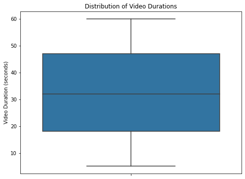

```python
# Create a boxplot to visualize the distribution of `video_duration_sec`
plt.figure(figsize=(8, 6))  # Adjust figure size for better readability
sns.boxplot(y=data['video_duration_sec'])
plt.title('Distribution of Video Durations')
plt.ylabel('Video Duration (seconds)')
plt.show()
```

Create a histogram of the values in the `video_duration_sec` column to further explore the distribution of this variable.

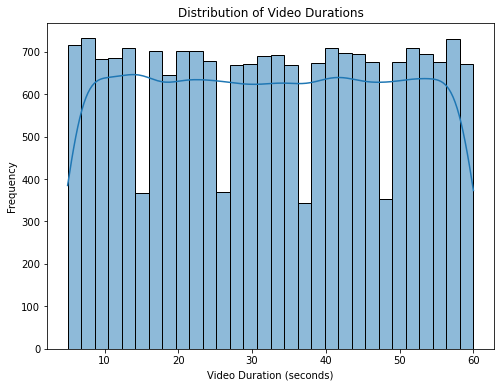

```python
# Create a histogram of `video_duration_sec`
plt.figure(figsize=(8, 6)) # Adjust figure size for better readability
sns.histplot(data['video_duration_sec'], bins=30, kde=True)  # Adjust the number of bins as needed
plt.title('Distribution of Video Durations')
plt.xlabel('Video Duration (seconds)')
plt.ylabel('Frequency')
plt.show()
```

#### **video_view_count**

Create a box plot to examine the spread of values in the `video_view_count` column.

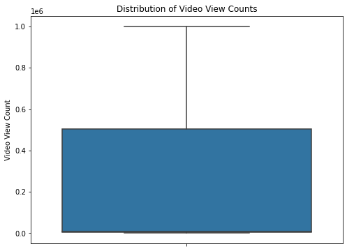

```python
# Create a boxplot to visualize the distribution of `video_view_count`
plt.figure(figsize=(8, 6))
sns.boxplot(y=data['video_view_count'])
plt.title('Distribution of Video View Counts')
plt.ylabel('Video View Count')
plt.show()
```

Create a histogram of the values in the `video_view_count` column to further explore the distribution of this variable.

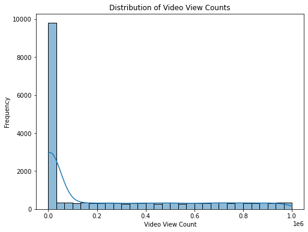

```python
# Create a histogram of `video_view_count`
plt.figure(figsize=(8, 6))
sns.histplot(data['video_view_count'], bins=30, kde=True)
plt.title('Distribution of Video View Counts')
plt.xlabel('Video View Count')
plt.ylabel('Frequency')
plt.show()
```

#### **video_like_count**

Create a box plot to examine the spread of values in the `video_like_count` column.

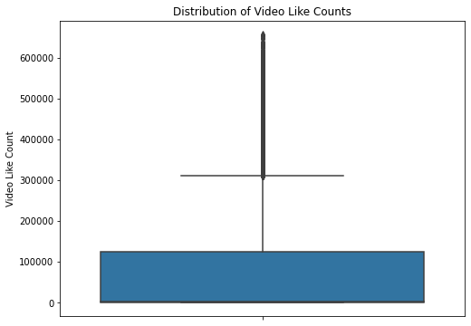

```python
# Create a boxplot to visualize the distribution of `video_like_count`
plt.figure(figsize=(8, 6))
sns.boxplot(y=data['video_like_count'])
plt.title('Distribution of Video Like Counts')
plt.ylabel('Video Like Count')
plt.show()
```

Create a histogram of the values in the `video_like_count` column to further explore the distribution of this variable.

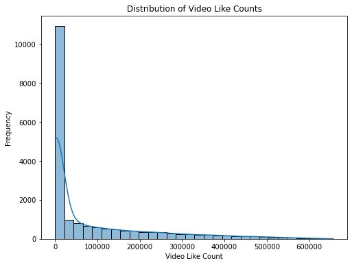

```python
# Create a histogram of `video_like_count`
plt.figure(figsize=(8, 6))
sns.histplot(data['video_like_count'], bins=30, kde=True)
plt.title('Distribution of Video Like Counts')
plt.xlabel('Video Like Count')
plt.ylabel('Frequency')
plt.show()
```

In summary, the video_like_count distribution is characterized by a large number of videos with few likes and a small number of videos with many likes.

#### **video_comment_count**

Create a box plot to examine the spread of values in the `video_comment_count` column.

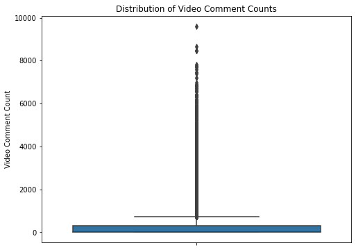

```python
# Create a boxplot to examine the spread of values in the `video_comment_count` column.
plt.figure(figsize=(8, 6))
sns.boxplot(y=data['video_comment_count'])
plt.title('Distribution of Video Comment Counts')
plt.ylabel('Video Comment Count')
plt.show()
```

Create a histogram of the values in the `video_comment_count` column to further explore the distribution of this variable.

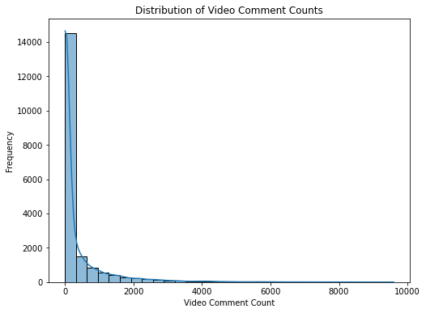

```python
# Create a histogram of the values in the `video_comment_count` column
plt.figure(figsize=(8, 6))
sns.histplot(data['video_comment_count'], bins=30, kde=True)
plt.title('Distribution of Video Comment Counts')
plt.xlabel('Video Comment Count')
plt.ylabel('Frequency')
plt.show()
```

In summary, the video_comment_count distribution is characterized by a large number of videos with few comments and a small number of videos with many comments.

#### **video_share_count**

Create a box plot to examine the spread of values in the `video_share_count` column.

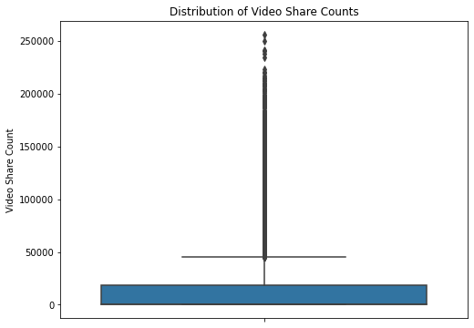

```python
# Create a box plot to examine the spread of values in the `video_share_count` column.
plt.figure(figsize=(8, 6))
sns.boxplot(y=data['video_share_count'])
plt.title('Distribution of Video Share Counts')
plt.ylabel('Video Share Count')
plt.show()
```

*Create* a histogram of the values in the `video_share_count` column to further explore the distribution of this variable.

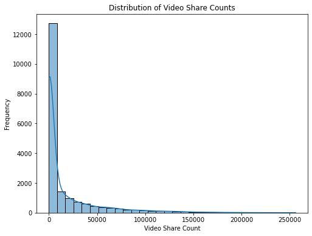

```python
# Create a histogram of the values in the `video_share_count` column
plt.figure(figsize=(8, 6))
sns.histplot(data['video_share_count'], bins=30, kde=True)
plt.title('Distribution of Video Share Counts')
plt.xlabel('Video Share Count')
plt.ylabel('Frequency')
plt.show()
```

In summary, the video_share_count distribution is characterized by a large number of videos with few shares and a small number of videos with many shares.

#### **video_download_count**

Create a box plot to examine the spread of values in the `video_download_count` column.

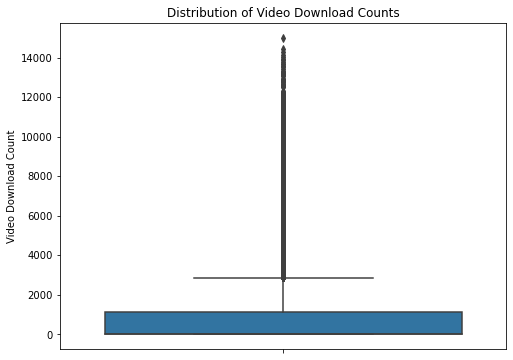

```python
# Create a box plot to examine the spread of values in the `video_download_count` column.
plt.figure(figsize=(8, 6))
sns.boxplot(y=data['video_download_count'])
plt.title('Distribution of Video Download Counts')
plt.ylabel('Video Download Count')
plt.show()
```

Create a histogram of the values in the `video_download_count` column to further explore the distribution of this variable.

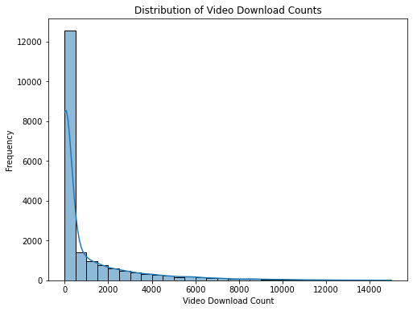

```python
# Create a histogram of the values in the `video_download_count` column
plt.figure(figsize=(8, 6))
sns.histplot(data['video_download_count'], bins=30, kde=True)
plt.title('Distribution of Video Download Counts')
plt.xlabel('Video Download Count')
plt.ylabel('Frequency')
plt.show()
```

In summary, the video_download_count distribution is characterized by a large number of videos with few downloads and a small number of videos with many downloads

#### **Claim status by verification status**

Now, create a histogram with four bars: one for each combination of claim status and verification status.

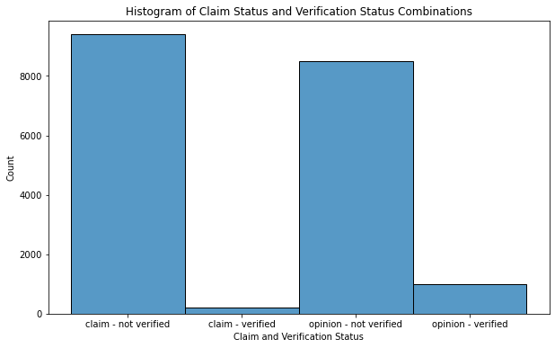

```python
# Create a histogram with four bars: one for each combination of claim status and verification status.
import matplotlib.pyplot as plt
import seaborn as sns

plt.figure(figsize=(10, 6))

# Filter the data to include only the four combinations you want to visualize
filtered_data = data[data['claim_status'].isin(['claim', 'opinion']) & data['verified_status'].isin(['not verified', 'verified'])]

# Create a new column combining claim_status and verified_status for easier plotting
filtered_data['status_combination'] = filtered_data['claim_status'] + ' - ' + filtered_data['verified_status']

# Create the histogram
sns.histplot(data=filtered_data, x='status_combination')

plt.title('Histogram of Claim Status and Verification Status Combinations')
plt.xlabel('Claim and Verification Status')
plt.ylabel('Count')

plt.show()
```

In summary:

Compare the number of "verified" posts to "not verified" posts to understand the number of verified vs unverified users. Compare the proportion of "opinion" posts within each verification status to understand the likelihood of posting opinions.

#### **Claim status by author ban status**

The previous course used a `groupby()` statement to examine the count of each claim status for each author ban status. Now, use a histogram to communicate the same information.

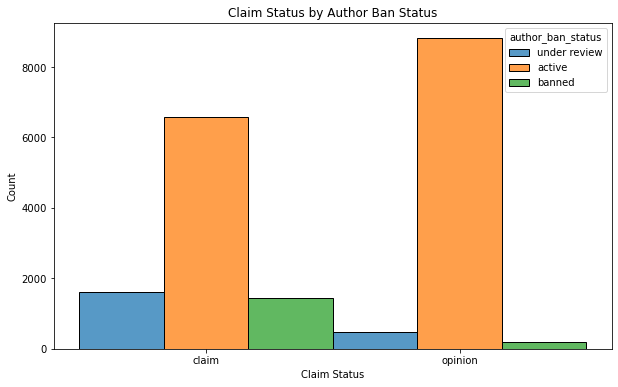

```python
# Create a histogram to show the count of each claim status for each author ban status
plt.figure(figsize=(10, 6))
sns.histplot(data=data, x='claim_status', hue='author_ban_status', multiple="dodge")
plt.title('Claim Status by Author Ban Status')
plt.xlabel('Claim Status')
plt.ylabel('Count')
plt.show()
```

Active vs. Banned Authors: The histogram shows the count of claims and opinions separately for active and banned authors. We can compare the heights of the bars for "active" and "banned" within each claim status (claim and opinion) to see the relative numbers. Claims and Opinions: We can also compare the number of claims versus opinions posted by both active and banned authors.

In general, you'd look for these trends:

Are there more active authors than banned authors overall? Do banned authors tend to post more claims or more opinions compared to active authors? By comparing the bar heights, you can get a good visual sense of these relationships.

#### **Median view counts by ban status**

Create a bar plot with three bars: one for each author ban status. The height of each bar should correspond with the median number of views for all videos with that author ban status.

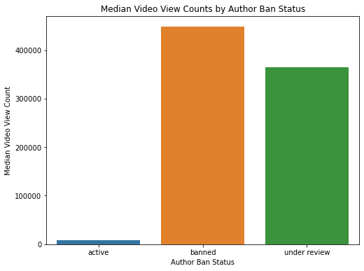

```python
# Calculate the median view counts for each author ban status
median_views = data.groupby('author_ban_status')['video_view_count'].median().reset_index()

# Create a bar plot
plt.figure(figsize=(8, 6))
sns.barplot(x='author_ban_status', y='video_view_count', data=median_views)
plt.title('Median Video View Counts by Author Ban Status')
plt.xlabel('Author Ban Status')
plt.ylabel('Median Video View Count')
plt.show()
```

In summary:

Compare the bar heights to see the difference in median view counts. If a relationship exists, video_view_count could potentially be a good indicator of claim status.

By examining the bar plot, you can determine if there's a noticeable difference in median view counts between active and banned authors, and how that insight might relate to predicting claim status.

```python
# Calculate the median view count for each claim status
median_views_by_claim_status = data.groupby('claim_status')['video_view_count'].median()
```

```python
# Print the result
print(median_views_by_claim_status)
```

```
claim_status
claim      501555.0
opinion      4953.0
Name: video_view_count, dtype: float64
```

#### **Total views by claim status**

Create a pie graph that depicts the proportions of total views for claim videos and total views for opinion videos.

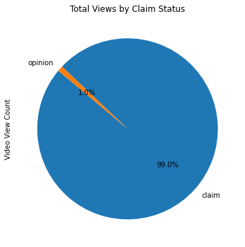

```python
# Calculate total views for each claim status
total_views_by_claim_status = data.groupby('claim_status')['video_view_count'].sum()

# Create a pie chart
plt.figure(figsize=(8, 6))
plt.pie(total_views_by_claim_status, labels=total_views_by_claim_status.index, autopct='%1.1f%%', startangle=140)
plt.title('Total Views by Claim Status')
plt.ylabel('Video View Count')  # Add y-axis label
plt.show()
```

Here's what we can observe:

Proportions: The pie chart shows the proportion of total views for 'claim' videos and 'opinion' videos. Overall View Count: By comparing the sizes of the slices, we can see which claim status has a larger share of the total views. In general, you'll likely notice that one slice is significantly larger than the other, indicating that one claim status has a much higher overall view count.

In summary, the pie chart visually represents how total views are distributed between 'claim' and 'opinion' videos, allowing you to quickly understand which status has the larger audience.

### **Task 4. Determine outliers**

When building predictive models, the presence of outliers can be problematic. For example, if you were trying to predict the view count of a particular video, videos with extremely high view counts might introduce bias to a model. Also, some outliers might indicate problems with how data was captured or recorded.

The ultimate objective of the TikTok project is to build a model that predicts whether a video is a claim or opinion. The analysis you've performed indicates that a video's engagement level is strongly correlated with its claim status. There's no reason to believe that any of the values in the TikTok data are erroneously captured, and they align with expectation of how social media works: a very small proportion of videos get super high engagement levels. That's the nature of viral content.

Nonetheless, it's good practice to get a sense of just how many of your data points could be considered outliers. The definition of an outlier can change based on the details of your project, and it helps to have domain expertise to decide a threshold. You've learned that a common way to determine outliers in a normal distribution is to calculate the interquartile range (IQR) and set a threshold that is 1.5 * IQR above the 3rd quartile.

In this TikTok dataset, the values for the count variables are not normally distributed. They are heavily skewed to the right. One way of modifying the outlier threshold is by calculating the **median** value for each variable and then adding 1.5 * IQR. This results in a threshold that is, in this case, much lower than it would be if you used the 3rd quartile.

Write a for loop that iterates over the column names of each count variable. For each iteration:

1. Calculate the IQR of the column
2. Calculate the median of the column
3. Calculate the outlier threshold (median + 1.5 * IQR)
4. Calculate the numer of videos with a count in that column that exceeds the outlier threshold
5. Print "Number of outliers, {column name}: {outlier count}"

```
Example:
Number of outliers, video_view_count: ___
Number of outliers, video_like_count: ___
Number of outliers, video_share_count: ___
Number of outliers, video_download_count: ___
Number of outliers, video_comment_count: ___
```

```python
# List of count variable names
count_variables = ['video_view_count', 'video_like_count', 'video_share_count', 'video_download_count', 'video_comment_count']

# For loop to iterate over each count variable
for column_name in count_variables:
    # Calculate the IQR
    Q1 = data[column_name].quantile(0.25)
    Q3 = data[column_name].quantile(0.75)
    IQR = Q3 - Q1

    # Calculate the median
    median_value = data[column_name].median()

    # Calculate the outlier threshold
    outlier_threshold = median_value + 1.5 * IQR

    # Calculate the number of videos with a count exceeding the outlier threshold
    outlier_count = (data[column_name] > outlier_threshold).sum()

    # Print the result
    print(f"Number of outliers, {column_name}: {outlier_count}")
```

```
Number of outliers, video_view_count: 2343
Number of outliers, video_like_count: 3468
Number of outliers, video_share_count: 3732
Number of outliers, video_download_count: 3733
Number of outliers, video_comment_count: 3882
```

#### **Scatterplot**

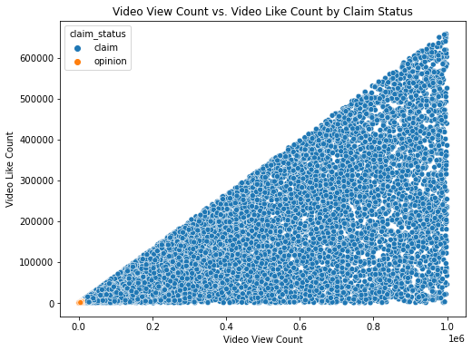

```python
# Create a scatterplot of `video_view_count` versus `video_like_count` according to 'claim_status'
plt.figure(figsize=(8, 6))
sns.scatterplot(x='video_view_count', y='video_like_count', hue='claim_status', data=data)
plt.title('Video View Count vs. Video Like Count by Claim Status')
plt.xlabel('Video View Count')
plt.ylabel('Video Like Count')
plt.show()
```

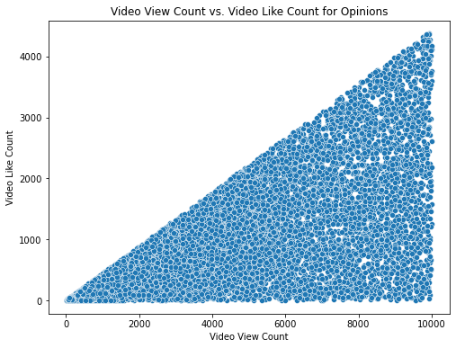

```python
# Create a scatterplot of `video_view_count` versus `video_like_count` for opinions only
plt.figure(figsize=(8, 6))
sns.scatterplot(x='video_view_count', y='video_like_count', data=data[data['claim_status'] == 'opinion'])
plt.title('Video View Count vs. Video Like Count for Opinions')
plt.xlabel('Video View Count')
plt.ylabel('Video Like Count')
plt.show()
```

You can do a scatterplot in Tableau Public as well, which can be easier to manipulate and present. If you'd like step by step instructions, you can review the instructions linked in the previous Activity page.

## **PACE: Execute**

Consider the questions in your PACE Strategy Document to reflect on the Execute stage.

### **Task 5a. Results and evaluation**

Having built visualizations in Tableau and in Python, what have you learned about the dataset? What other questions have your visualizations uncovered that you should pursue?

*Pro tip:* Put yourself in your client's perspective, what would they want to know?

Use the following code cells to pursue any additional EDA. Also use the space to make sure your visualizations are clean, easily understandable, and accessible.

*Ask yourself:* Did you consider color, contrast, emphasis, and labeling?

Key Learnings:

Why do claims get more views? How does being banned affect engagement? What are the characteristics of high-engagement claims vs. opinions? How does verification influence content type and reach? What topics are common in claims vs. opinions? Do engagement patterns by ban status differ for claims and opinions? Client Focus:

Clients would likely want to know:

Which video types are popular? Are claims more likely to go viral? Does verification matter? Can engagement help identify claims? What's the impact of bans on visibility? Accessibility:

Visualizations should use colorblind-friendly palettes, high contrast, clear labels, and annotations for emphasis. For Tableau, ensure alternative text for visual elements.

### **Task 5b. Conclusion**

*Make it professional and presentable*

You have visualized the data you need to share with the director now. Remember, the goal of a data visualization is for an audience member to glean the information on the chart in mere seconds.

*Questions to ask yourself for reflection:* Why is it important to conduct Exploratory Data Analysis? What other visuals could you create?

EDA stands for Exploratory Data Analysis.

Essentially, it's the initial process of investigating and summarizing a dataset to:

Understand its main characteristics. Identify patterns and relationships between variables. Detect outliers and anomalies. Test underlying assumptions. Formulate hypotheses for further analysis. Decide which statistical tools and techniques are most appropriate. Prepare the data for modeling. Think of it like getting to know someone before starting a serious relationship. You ask questions, observe their behavior, and try to understand their quirks and traits. EDA is the same for data.

It typically involves:

Looking at the raw data: Examining the first few rows, data types, and overall structure. Calculating descriptive statistics: Mean, median, standard deviation, quartiles, etc., to summarize the central tendency and spread of the data. Visualizing the data: Using charts and graphs (histograms, box plots, scatter plots, bar charts) to identify patterns, distributions, and relationships. Handling missing values and outliers: Identifying them and deciding on appropriate strategies (imputation, removal, transformation).

Exploring relationships between variables: Using correlation analysis and visualizations. In short, EDA is a crucial first step in any data analysis project because it provides the foundation for all subsequent work and helps ensure that the insights derived are accurate and meaningful.

You’ve now completed a professional data visualization according to a business need. Well done! Be sure to save your work as a reference for later work in Tableau.

**Congratulations!** You've completed this lab. However, you may not notice a green check mark next to this item on Coursera's platform. Please continue your progress regardless of the check mark. Just click on the "save" icon at the top of this notebook to ensure your work has been logged.